# HW 03 - Legos

Jeannie Hinton

2/23/23

This homework assignment reviews some of the data wrangling skills we have been working on the past several weeks.

# Packages

In this assignment we will work with the `tidyverse` as usual:

```r
library(tidyverse)
```

## Lego sales

The data set `lego_sales` contains simulated lego set purchases in the U.S., based on actual prices, for the year 2018. The data set is called `lego_sales` and you can load it using the following code:

```r
load(file = "lego_sales.rda")
```

Each row in the data set represents a lego set purchase. The variables in this data set are as follows:

**first_name**: first name of customer

**last_name**: last name of customer

**age**: age of customer

**phone_number**: phone number of customer

**set_id**: ID of lego set purchased

**number**: item number of lego set purchased

**theme**: theme of lego set purchased

**subtheme**: sub-theme of lego set purchased

**year**: year of purchase

**name**: name of lego set purchased

**pieces**: number of pieces of legos in set purchased

**us_price**: price of set purchased, in U.S. dollars

**image_url**: image url of lego set purchased

**quantity**: quantity of lego sets purchased

Answer the following questions using pipelines. For each question, state your answer in a sentence, e.g. “The first three common names of purchasers are …”.

1. What are the three most common first names of purchasers?

```r
lego_sales %>%
  count(first_name) %>%
  arrange(desc(n))
```

```
## # A tibble: 211 × 2
##    first_name     n
##    <chr>      <int>
##  1 Jackson       13
##  2 Jacob         11
##  3 Joseph        11
##  4 Michael       10
##  5 Audrey         8
##  6 Connor         8
##  7 Kaitlyn        8
##  8 Lucas          8
##  9 Amanda         7
## 10 Joshua         7
## # … with 201 more rows
```

**The first three common names of purchasers are Jackson, Jacob, and Joseph.** 2. What are the three most common themes of lego sets purchased?

```r
lego_sales %>%
  count(theme) %>%
  arrange(desc(n))
```

```
## # A tibble: 25 × 2
##    theme            n
##    <chr>        <int>
##  1 Star Wars       75
##  2 Nexo Knights    64
##  3 Gear            55
##  4 Mixels          55
##  5 City            45
##  6 Friends         42
##  7 Ninjago         38
##  8 Duplo           35
##  9 Bionicle        34
## 10 Creator         25
## # … with 15 more rows
```

**The three most common themes are Star Wars, Nexo Knights, and Mixels.**

3. Among the most common themes of lego sets purchased, what is the most common subtheme? *Hint:* use your answer from question 2 to filter the data.

```r
lego_sales %>%
  filter(theme == "Star Wars" | theme == "Nexo Knights" | theme == "Gear") %>%
  count(subtheme) %>%
  arrange(desc(n))
```

```
## # A tibble: 27 × 2
##    subtheme              n
##    <chr>             <int>
##  1 <NA>                 42
##  2 Ultimate             22
##  3 The Force Awakens    15
##  4 Buildable Figures    11
##  5 Episode V            10
##  6 MicroFighters        10
##  7 Battlefront           7
##  8 Original Content      7
##  9 Role-Play toys        7
## 10 Stationery            7
## # … with 17 more rows
```

**The most common sub themes are Ulitimate, The Force Awakens, and Buildable Figures.**

4. Create a new variable called `age_group` and group the ages into the following categories: “18 and under”, “19 - 25”, “26 - 35”, “36 - 50”, “51 and over”. *Hint:* Use the `case_when()` function: [case-when-doc](https://www.rdocumentation.org/packages/dplyr/versions/0.7.8/topics/case_when)

```r
lego_sales <- lego_sales %>%
  mutate(age_group = case_when(
    age <= 18 ~ "18 and under",
    age >= 19 & age <= 25 ~ "19 - 25",
    age >= 26 & age <= 35 ~ "26 - 35",
    age >= 36 & age <= 50 ~ "36 - 50",
    age >= 51 ~ "51 and over"))
```

5. Which age group has purchased the highest total number of lego sets? *Hint:* some purchases are for more than one lego set, so it is not sufficient to just count the number of observations in each age category.

```r
lego_sales %>%
  group_by(age_group) %>%
  summarize(most_purchasing = sum(quantity)) %>%
  arrange(desc(most_purchasing))
```

```
## # A tibble: 5 × 2
##   age_group    most_purchasing
##   <chr>                  <dbl>
## 1 36 - 50                  313
## 2 26 - 35                  267
## 3 19 - 25                  174
## 4 51 and over               92
## 5 18 and under              45
```

**The 36-50 years old is the age group with the most set purchases.**

6. Which age group has spent the most money on legos?

```r
lego_sales %>%
  group_by(age_group) %>%
  summarize(most_money_spent = sum(us_price)) %>%
  arrange(desc(most_money_spent))
```

```
## # A tibble: 5 × 2
##   age_group    most_money_spent
##   <chr>                   <dbl>
## 1 36 - 50                 6642.
## 2 26 - 35                 5260.
## 3 19 - 25                 3630.
## 4 51 and over             1832.
## 5 18 and under             642.
```

**The 36-50 years old is the age group with the most money spent on lego purchases.**

7. Come up with a question you want to answer using these data, and write it down. Then, create a data visualization that answers the question, and explain how your visualization answers the question.

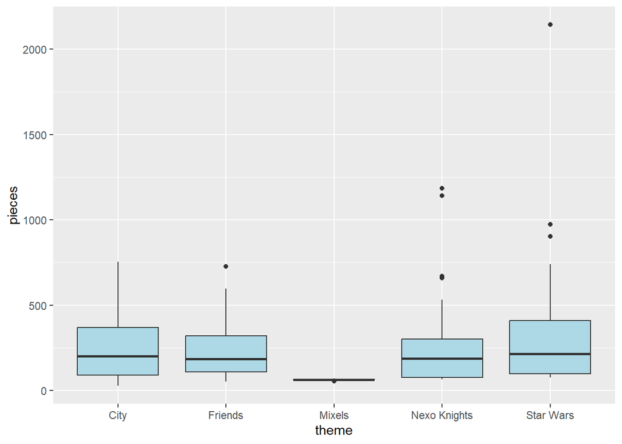

```r
lego_sales %>%
  filter(theme == "Star Wars" | theme == "Nexo Knights" |  theme == "Mixels" |
         theme == "City" |  theme == "Friends") %>%
ggplot(aes(x = theme, y = pieces)) +
geom_boxplot(fill = "lightblue")
```